# Dental Data Mixed Model

## Dental data mixed model

This notebook pertains to the file BIOS-767-Part-011.pdf.

### Data manipulation

We first convert the data to “long” format

```r
options(contrasts = c(factor = "contr.SAS", ordered = "contr.poly"))
library(sas7bdat)
setwd('C:/Users/psioda/Documents/GitHub/bios-courses/BIOS-767/DATA/DENTAL')
dental.wide = read.sas7bdat('dental.sas7bdat')
names(dental.wide) = tolower(names(dental.wide))

## change to long format
library(tidyverse)
dental.long = dental.wide %>%
  pivot_longer(cols = c(age8, age10, age12, age14),
               names_to = 'age', names_prefix = 'age', values_to = 'distance')
dental.long$gender = factor(dental.long$gender)
dental.long$age    = as.numeric(dental.long$age)
dental.long$id     = factor(dental.long$id)
head(dental.long)
```

```
## # A tibble: 6 x 4
##   id    gender   age distance
##   <fct> <fct>  <dbl>    <dbl>
## 1 1     F          8     21
## 2 1     F         10     20
## 3 1     F         12     21.5
## 4 1     F         14     23
## 5 2     F          8     21
## 6 2     F         10     21.5
```

### Random intercept / slope model

The following code repeats the analysis conducted in BIOS-767-Part-011.

There are several packages to conduct mixed effects models in R. One of the more flexible ones is `nlme`, the same package that uses the `gls` function. Another popular package with simple syntax (but less flexibility) is `lme4`.

We will proceed with the `nlme` package.

```r
library(nlme)
## Fit random intercept model
nlme.randint = nlme::lme(
  fixed       = distance ~ 0 + gender + age:gender,
  random      = ~ 1 | id,   ## random intercept
  method      = 'REML',
  control     = lmeControl(msMaxIter = 200, msMaxEval = 500, sing.tol=1e-20, opt = 'optim'),
  data        = dental.long,
  weights     = varIdent(form = ~ 1 | gender )   ## says variances differ by gender
)

## Fit random slope model
nlme.randslope = nlme::lme(
  fixed       = distance ~ 0 + gender + age:gender,
  random      = ~ 1 + age | id,
  method      = 'REML',
  control     = lmeControl(msMaxIter = 200, msMaxEval = 500, sing.tol=1e-20, opt = 'optim'),
  data        = dental.long,
  weights     = varIdent(form = ~ 1 | gender )     ## says variances differ by gender
)

## Construct LRT test statistic
logLik0 = 2 * as.numeric( logLik(nlme.randint, REML = T) )
logLik1 = 2 * as.numeric( logLik(nlme.randslope, REML = T) )
c('randint' = logLik0, 'randslope' = logLik1)
```

```
##   randint randslope
## -415.2205 -411.5225
```

```r
LRT.nlme = -(logLik0 - logLik1)
LRT.nlme
```

```
## [1] 3.697969
```

We can obtain the covariance matrices as follows

```r
getVarCov(nlme.randslope, type = 'random.effects', individual = 1)
```

```
## Random effects variance covariance matrix
##             (Intercept)       age
## (Intercept)     3.88130 -0.154320
## age            -0.15432  0.024419
##   Standard Deviations: 1.9701 0.15626
```

```r
getVarCov(nlme.randslope, type = 'conditional', individual = 1)
```

```
## id 1
## Conditional variance covariance matrix
##         1       2       3       4
## 1 0.44447 0.00000 0.00000 0.00000
## 2 0.00000 0.44447 0.00000 0.00000
## 3 0.00000 0.00000 0.44447 0.00000
## 4 0.00000 0.00000 0.00000 0.44447
##   Standard Deviations: 0.66669 0.66669 0.66669 0.66669
```

```r
getVarCov(nlme.randslope, type = 'marginal', individual = 1)
```

```
## id 1
## Marginal variance covariance matrix
##        1      2      3      4
## 1 3.4195 3.0571 3.1391 3.2212
## 2 3.0571 3.6813 3.4166 3.5963
## 3 3.1391 3.4166 4.1385 3.9714
## 4 3.2212 3.5963 3.9714 4.7910
##   Standard Deviations: 1.8492 1.9187 2.0343 2.1888
```

```r
getVarCov(nlme.randslope, type = 'marginal', individual = 20)
```

```
## id 20
## Marginal variance covariance matrix
##        1      2      3      4
## 1 5.6300 3.0571 3.1391 3.2212
## 2 3.0571 5.8918 3.4166 3.5963
## 3 3.1391 3.4166 6.3490 3.9714
## 4 3.2212 3.5963 3.9714 7.0015
##   Standard Deviations: 2.3728 2.4273 2.5197 2.646
```

```r
dental.long %>% filter(id %in% c(1, 20))
```

```
## # A tibble: 8 x 4
##   id    gender   age distance
##   <fct> <fct>  <dbl>    <dbl>
## 1 1     F          8     21
## 2 1     F         10     20
## 3 1     F         12     21.5
## 4 1     F         14     23
## 5 20    M          8     23
## 6 20    M         10     20.5
## 7 20    M         12     31
## 8 20    M         14     26
```

Note that the gender is different between subjects 1 and 20, and also the variance is different.

## summary

```r
summary(nlme.randslope)
```

```
## Linear mixed-effects model fit by REML
##   Data: dental.long
##        AIC     BIC    logLik
##   429.5225 453.322 -205.7613
##
## Random effects:
##  Formula: ~1 + age | id
##  Structure: General positive-definite, Log-Cholesky parametrization
##             StdDev    Corr
## (Intercept) 1.9700946 (Intr)
## age         0.1562648 -0.501
## Residual    0.6666891
##
## Variance function:
##  Structure: Different standard deviations per stratum
##  Formula: ~1 | gender
##  Parameter estimates:
##        F        M
## 1.000000 2.444041
## Fixed effects:  distance ~ 0 + gender + age:gender
##                 Value Std.Error DF   t-value p-value
## genderF     17.372727 0.7793623 25 22.290953       0
## genderM     16.340625 1.1348937 25 14.398375       0
## genderF:age  0.479545 0.0651170 80  7.364371       0
## genderM:age  0.784375 0.0991112 80  7.914092       0
##  Correlation:
##             gendrF gendrM gndrF:
## genderM      0.000
## genderF:age -0.714  0.000
## genderM:age  0.000 -0.897  0.000
##
## Standardized Within-Group Residuals:
##         Min          Q1         Med          Q3         Max
## -2.89974788 -0.49967452  0.03975323  0.51848751  3.10755306
##
## Number of Observations: 108
## Number of Groups: 27
```

### Residuals

A (standardized) residuals vs. fitted values plot may be obtained by simply calling the `plot` method on a `lme` object.

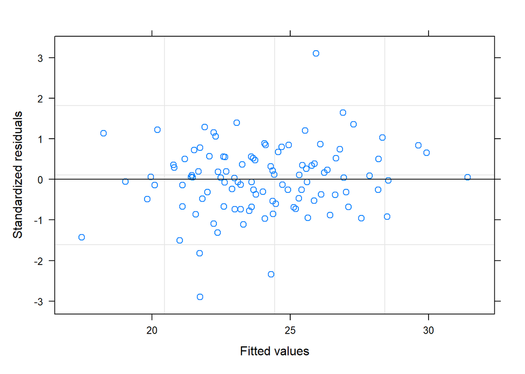

```r
plot(nlme.randslope)
```

Alternatively, we can use the `residplot` function in the `predictmeans` package for other diagnostics

```r
library(predictmeans)
residplot(nlme.randslope)
```

Unfortunately, this plot will not render when knitted, but it includes a normal plot for the random intercept, normal plot for residuals, residuals vs. fitted, and fitted vs. observed.

### Scaled residuals

Now, we compute the scaled residuals using the Cholesky decomposition

```r
N           = nrow(dental.wide)
n           = nrow(dental.long)
resid       = residuals(nlme.randslope,type="response")
scaledResid = numeric(n);
scaledDep   = numeric(n)
for ( i in 1:N ) {
  ## Get covariance matrix for subject i; take cholesky decomposition
  Sigma_i  = getVarCov(nlme.randslope, individual = i, type = 'marginal')
  L_i      = t( chol(Sigma_i[[1]]) )

  ## Obtain residual for ith individual
  di  <- dental.long[which(dental.long$id==i),]
  x   <- cbind((di$gender=="F")*1.0,(di$gender=="M")*1.0,(di$gender=="F")*di$age,(di$gender=="M")*di$age)
  resid_i  = di$distance - x%*%c(unlist(coef(nlme.randslope)[i,1:4]))


  if (i==1) print(Sigma_i[[1]])
  if (i==1) print(L_i)
  if (i==1) print(resid_i)

  ## Compute scaled residual
  scaledResid[dental.long$id == i] = solve(L_i) %*% resid_i

  if (i==1) print(scaledResid[dental.long$id == i])

  scaledDep[dental.long$id == i]   = solve(L_i) %*% dental.long[dental.long$id == i,]$distance
}
```

```
##          1        2        3        4
## 1 3.419485 3.057078 3.139145 3.221211
## 2 3.057078 3.681294 3.416561 3.596302
## 3 3.139145 3.416561 4.138452 3.971394
## 4 3.221211 3.596302 3.971394 4.790959
##          1         2         3         4
## 1 1.849185 0.0000000 0.0000000 0.0000000
## 2 1.653203 0.9737630 0.0000000 0.0000000
## 3 1.697583 0.6265513 0.9295686 0.0000000
## 4 1.741963 0.7357899 0.5951768 0.9278485
##            [,1]
## [1,] -0.2090909
## [2,] -2.1681818
## [3,] -1.6272727
## [4,] -1.0863636
## [1] -0.1130719 -2.0346338 -0.1726836  0.7656893
```

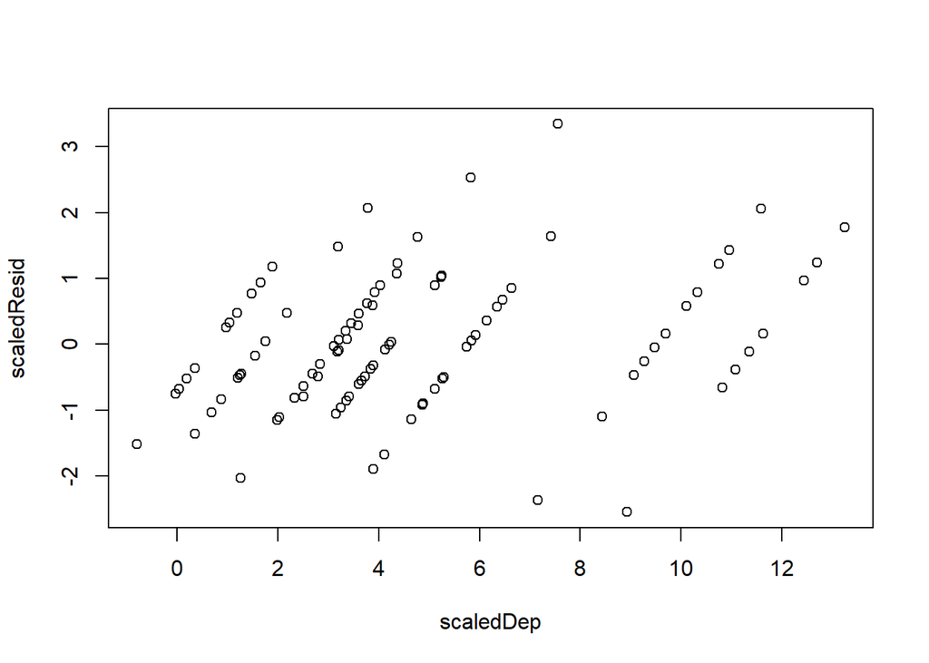

```r
#print(cbind(dental.long$id,dental.long$age,scaledDep,scaledResid))
plot(scaledDep,scaledResid)
```

We can now compute the Mahalanobis distances

```r
library(kableExtra)
md   = numeric(n)
pval = numeric(n)
for ( i in 1:n ) {
  md[i]   = sum( scaledResid[dental.long$id == i]^2 )
  rm_i    = sum(dental.long$id == i)  ## number of repeated measures for subject i
  pval[i] = pchisq(md[i], df = rm_i, lower.tail = F)
}
res = data.frame('ID' = dental.wide$id, 'Mahalanobis' = md, 'pval' = pval)
res = res %>% arrange(desc(Mahalanobis))
res %>% mutate(Significant = ifelse(pval < .05, '*', ''))
```

```
##     ID Mahalanobis       pval Significant
## 1   20  16.1164342 0.00286684           *
## 2   24  11.9666978 0.01760063           *
## 3   10   8.3568111 0.07934829
## 4   11   7.5873710 0.10791775
## 5    3   7.0036070 0.13569773
## 6   21   5.6402756 0.22767154
## 7    1   4.7686196 0.31187282
## 8   15   4.0518161 0.39903872
## 9    2   3.8338491 0.42895867
## 10  12   3.7052487 0.44736299
## 11  19   3.4366819 0.48757107
## 12   8   2.8207980 0.58824797
## 13   9   2.7345766 0.60317785
## 14  16   2.5639023 0.63323080
```

[output cut: 94 more lines]

### Influence Measures

The package `HLMdiag` provides residual diagnostics for `lme` objects. A nice vignette of the package is available here: https://cran.r-project.org/web/packages/HLMdiag/vignettes/influence_diagnostics.html

Note that the implementation performs one-step influence diagnostics

```r
library(HLMdiag)
infl = hlm_influence(nlme.randslope, level = 'id')
infl
```

```
## # A tibble: 27 x 6
##    id     cooksd mdffits covtrace covratio leverage.overall
##    <fct>   <dbl>   <dbl>    <dbl>    <dbl>            <dbl>
##  1 1     0.0151  0.0138     0.200     1.21            0.375
##  2 2     0.0621  0.0565     0.200     1.21            0.375
##  3 3     0.0812  0.0738     0.200     1.21            0.375
##  4 4     0.0421  0.0383     0.200     1.21            0.375
##  5 5     0.0266  0.0242     0.200     1.21            0.375
##  6 6     0.0199  0.0181     0.200     1.21            0.375
##  7 7     0.00320 0.00291    0.200     1.21            0.375
##  8 8     0.0729  0.0663     0.200     1.21            0.375
##  9 9     0.0334  0.0304     0.200     1.21            0.375
## 10 10    0.140   0.127      0.200     1.21            0.375
## # ... with 17 more rows
```

We can create plots

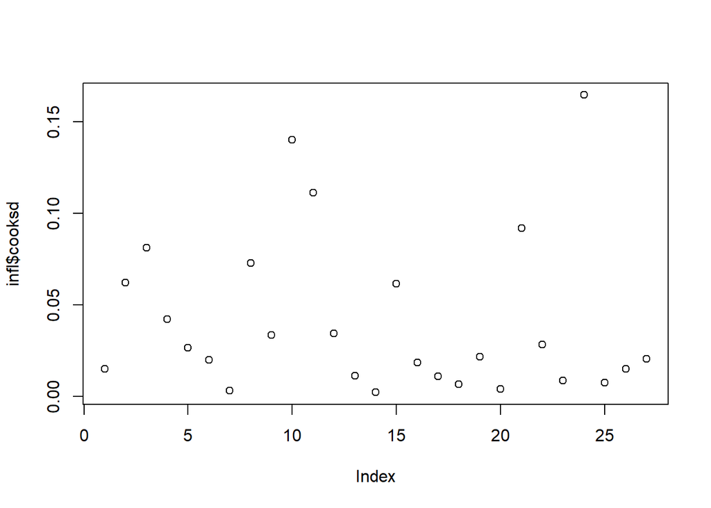

```r
plot(infl$cooksd)
```

### Analysis Code using LME4 package

```r
library(lme4)
library(lmerTest)

lmm <- lmerTest::lmer(distance ~ 0 + gender + age:gender + (1 + age | id), data = dental.long, REML = TRUE)
summary(lmm)
```

```
## Linear mixed model fit by REML. t-tests use Satterthwaite's method [
## lmerModLmerTest]
## Formula: distance ~ 0 + gender + age:gender + (1 + age | id)
##    Data: dental.long
##
## REML criterion at convergence: 432.6
##
## Scaled residuals:
##     Min      1Q  Median      3Q     Max
## -3.1694 -0.3862  0.0070  0.4454  3.8490
##
## Random effects:
##  Groups   Name        Variance Std.Dev. Corr
##  id       (Intercept) 5.77449  2.4030
##           age         0.03245  0.1801   -0.67
##  Residual             1.71663  1.3102
## Number of obs: 108, groups:  id, 27
##
## Fixed effects:
##             Estimate Std. Error       df t value Pr(>|t|)
## genderF     17.37273    1.22805 25.00779  14.147 1.94e-13 ***
## genderM     16.34062    1.01825 25.00779  16.048 1.12e-14 ***
## genderF:age  0.47955    0.10370 25.01129   4.625 9.85e-05 ***
## genderM:age  0.78438    0.08598 25.01129   9.123 1.97e-09 ***
## ---
## Signif. codes:  0 '***' 0.001 '**' 0.01 '*' 0.05 '.' 0.1 ' ' 1
##
## Correlation of Fixed Effects:
##             gendrF gendrM gndrF:
## genderM      0.000
## genderF:age -0.880  0.000
## genderM:age  0.000 -0.880  0.000
```

### Test a contrast of the parameters using KR method

```r
lmerTest::contest(lmm,c(0,0,1,-1),ddf=c("Kenward-Roger"))
```

```
##     Sum Sq  Mean Sq NumDF DenDF F value     Pr(>F)
## 1 8.790563 8.790563     1    25 5.12084 0.03257912
```

### Compute summaries for beta using KR method

```r
drop1(lmm,ddf=c("Kenward-Roger"))
```

```
## Single term deletions using Kenward-Roger's method:
##
## Model:
## distance ~ 0 + gender + age:gender + (1 + age | id)
##            Sum Sq Mean Sq NumDF DenDF F value    Pr(>F)
## gender:age 179.57  89.788     2    25  52.305 1.165e-09 ***
## ---
## Signif. codes:  0 '***' 0.001 '**' 0.01 '*' 0.05 '.' 0.1 ' ' 1
```

### Compute predictions accounting for uncertainty

```r
eBlup <- predict(lmm, newdata = dental.long)
eBlup
```

```
##        1        2        3        4        5        6        7        8
## 20.20973 21.07933 21.94894 22.81854 21.27176 22.41112 23.55048 24.68984
##        9       10       11       12       13       14       15       16
## 21.86919 23.05509 24.24099 25.42690 23.09558 24.11126 25.12693 26.14261
##       17       18       19       20       21       22       23       24
## 21.33999 22.18937 23.03875 23.88813 19.99836 20.86134 21.72431 22.58729
##       25       26       27       28       29       30       31       32
## 21.45523 22.46124 23.46724 24.47325 22.04750 22.86341 23.67932 24.49523
##       33       34       35       36       37       38       39       40
## 20.07175 20.88138 21.69102 22.50066 17.72389 18.55732 19.39076 20.22419
##       41       42       43       44       45       46       47       48
## 24.21704 25.37915 26.54125 27.70336 24.84561 26.57640 28.30719 30.03797
##       49       50       51       52       53       54       55       56
## 21.27500 22.79652 24.31804 25.83956 22.03315 23.56452 25.09589 26.62726
##       57       58       59       60       61       62       63       64
## 24.46319 25.75077 27.03835 28.32593 20.90289 22.45449 24.00608 25.55767
##       65       66       67       68       69       70       71       72
## 23.88487 25.43254 26.98021 28.52787 21.57371 23.11850 24.66330 26.20809
##       73       74       75       76       77       78       79       80
## 21.99130 23.31270 24.63410 25.95551 22.60784 24.28241 25.95698 27.63155
##       81       82       83       84       85       86       87       88
## 26.47201 28.14248 29.81295 31.48342 21.81662 23.10473 24.39284 25.68094
##       89       90       91       92       93       94       95       96
## 21.84968 23.51440 25.17913 26.84385 21.15248 23.32396 25.49543 27.66690
##       97       98       99      100      101      102      103      104
## 22.72671 24.15462 25.58253 27.01044 23.13187 24.90633 26.68079 28.45525
##      105      106      107      108
## 21.12306 22.51463 23.90619 25.29776
```